"On my honor, as a student, I have neither given nor received unauthorized aid on this academic work."

# Basic Statistics (Stat 101) with Python

## What statistical techniques are available?

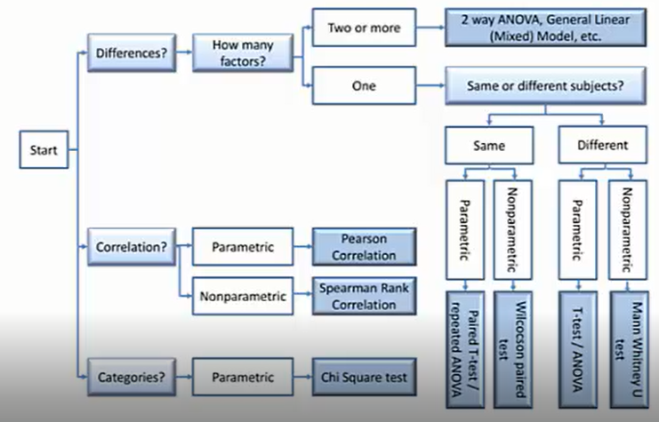

```python
from IPython.display import Image
Image("images/differentstatisticaltests.png")
# image source: www.coloss.org/beebook
```

## Goals

- Learn how to perform t-testing
- t-testing is used to find if there is any statically significant difference in the mean values of two samples
- help to answer many questions such as:
  - any difference in intelligence scores between male and female
  - any difference in cheating on spouse between religous people and people with no religion
  - any difference in profits between small-size models and luxurious hotels

## Assumptions of statistical tests

- Many statistical tests assume that the data is normally distributed
- Equal variances between different samples

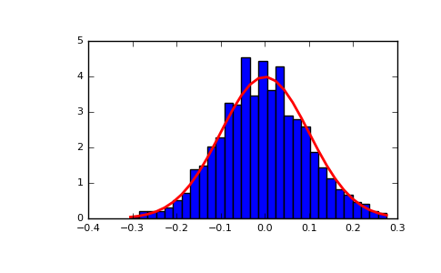

```python
# looks nornally distributed
Image("images/numpy-random-normal.png")
```

```python
# looks skewed
Image(url= "http://www.philender.com/courses/intro/notes3/cheby2.png")
```

[figure not shown]

```python
Image(url= "http://www.oftwominds.com/photos2014/long-tail2.png")
```

[figure not shown]

# Loading python packages

```python
import pandas as pd
import numpy as np
from scipy import stats
from pandas.tools import plotting
import matplotlib.pyplot as plt
%matplotlib inline
```

# Loading data

```python
# load tips.csv
tips = pd.read_csv('data/tips.csv')
tips.head()
```

|  | total_bill | tip | sex | smoker | day | time | size |
| --- | --- | --- | --- | --- | --- | --- | --- |
| 0 | 16.99 | 1.01 | Female | No | Sun | Dinner | 2 |
| 1 | 10.34 | 1.66 | Male | No | Sun | Dinner | 3 |
| 2 | 21.01 | 3.50 | Male | No | Sun | Dinner | 3 |
| 3 | 23.68 | 3.31 | Male | No | Sun | Dinner | 2 |
| 4 | 24.59 | 3.61 | Female | No | Sun | Dinner | 4 |

# Exploring data & Data visualization

```python
# basic stats
tips.describe()
```

|  | total_bill | tip | size |
| --- | --- | --- | --- |
| count | 244.000000 | 244.000000 | 244.000000 |
| mean | 19.785943 | 2.998279 | 2.569672 |
| std | 8.902412 | 1.383638 | 0.951100 |
| min | 3.070000 | 1.000000 | 1.000000 |
| 25% | 13.347500 | 2.000000 | 2.000000 |
| 50% | 17.795000 | 2.900000 | 2.000000 |
| 75% | 24.127500 | 3.562500 | 3.000000 |
| max | 50.810000 | 10.000000 | 6.000000 |

```python
# pivot for sex
tips.groupby('sex').mean()
```

| sex | total_bill | tip | size |
| --- | --- | --- | --- |
| Female | 18.056897 | 2.833448 | 2.459770 |
| Male | 20.744076 | 3.089618 | 2.630573 |

```python
# pivot with time
tips.groupby('time').mean()
```

| time | total_bill | tip | size |
| --- | --- | --- | --- |
| Dinner | 20.797159 | 3.102670 | 2.630682 |
| Lunch | 17.168676 | 2.728088 | 2.411765 |

```python
# pivot with day
tips.groupby('day').mean()
```

| day | total_bill | tip | size |
| --- | --- | --- | --- |
| Fri | 17.151579 | 2.734737 | 2.105263 |
| Sat | 20.441379 | 2.993103 | 2.517241 |
| Sun | 21.410000 | 3.255132 | 2.842105 |
| Thur | 17.682742 | 2.771452 | 2.451613 |

```python
# pivot with size
tips.groupby('size').mean()
```

| size | total_bill | tip |
| --- | --- | --- |
| 1 | 7.242500 | 1.437500 |
| 2 | 16.448013 | 2.582308 |
| 3 | 23.277632 | 3.393158 |
| 4 | 28.613514 | 4.135405 |
| 5 | 30.068000 | 4.028000 |
| 6 | 34.830000 | 5.225000 |

```
array([[<matplotlib.axes._subplots.AxesSubplot object at 0x000000000BD36390>,
      dtype=object)
```

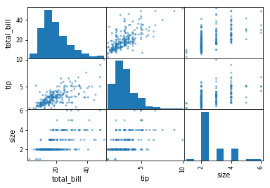

```python
# plot scatter matrix
plotting.scatter_matrix(tips[['total_bill', 'tip', 'size']])
```

# Statistical (Hypothesis) Testing

## Normality test

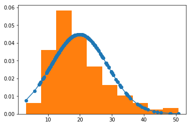

```python
# an illustration of normal distribution

h = sorted(tips['total_bill'])
fit = stats.norm.pdf(h, np.mean(h), np.std(h))  #this is a fitting indeed
plt.plot(h,fit,'-o')
plt.hist(h,normed=True)      #use this to draw histogram of your data
```

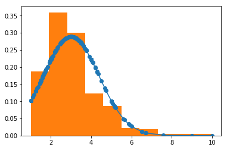

```python
# an illustration of normal distribution with tip

h = sorted(tips['tip'])
fit = stats.norm.pdf(h, np.mean(h), np.std(h))  #this is a fitting indeed
plt.plot(h,fit,'-o')
plt.hist(h,normed=True)      #use this to draw histogram of your data
```

```python
# test if the data is normally distributed

import scipy.stats as stats

print stats.normaltest(tips['total_bill'])
print stats.normaltest(tips['tip'])
```

```
NormaltestResult(statistic=45.11781912347332, pvalue=1.5951078766352608e-10)
NormaltestResult(statistic=79.37862574074785, pvalue=5.796294322907102e-18)
```

```python
# to print three decimals only
bill = stats.normaltest(tips['total_bill'])
tip = stats.normaltest(tips['tip'])

print "The chi-square statistic is %.3f and the p-value is %.3f." % bill
print "The chi-square statistic is %.3f and the p-value is %.3f." % tip
```

```
The chi-square statistic is 45.118 and the p-value is 0.000.
The chi-square statistic is 79.379 and the p-value is 0.000.
```

```python
# test if size is normally distributed

print stats.normaltest(tips['size'])
```

```
NormaltestResult(statistic=64.55815532237287, pvalue=9.580202540024401e-15)
```

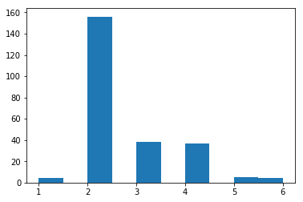

```python
# plot a histogram with size and see if the data is normally distributed
plt.hist(tips['size'])
```

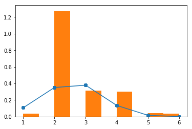

```python
h = sorted(tips['size'])
fit = stats.norm.pdf(h, np.mean(h), np.std(h))  #this is a fitting indeed
plt.plot(h,fit,'-o')
plt.hist(h,normed=True)
```

## t-test

- the most popular statical techique for hypothesis testing
- test if the mean (or average) of two groups or data samples is significantly different or not
- low p-value (< 0.01) is an indicator that there is significant difference in the two groups.

### 2-sample test

Our **null hypothesis** is that ther is no difference between male and female in terms of the amount of tips.

```python
female_tip = tips[tips['sex'] == 'Female']['tip']
male_tip = tips[tips['sex'] == 'Male']['tip']
stats.ttest_ind(female_tip, male_tip)
```

```
Ttest_indResult(statistic=-1.3878597054212687, pvalue=0.16645623503456763)
```

```python
#print three decimal points
two_sample = stats.ttest_ind(female_tip, male_tip)
print "The t-statistic is %.3f and the p-value is %.3f." % two_sample
```

```
The t-statistic is -1.388 and the p-value is 0.166.
```

- Null hypothesis says two means are almost same.
- p-value is a probability if the null hypothesis is true. A low p-value (< 0.01) means we can reject the null hypothesis
- Since we have a high p-value, we accept the null hypothesis that male and female give roughly same tips (No difference)

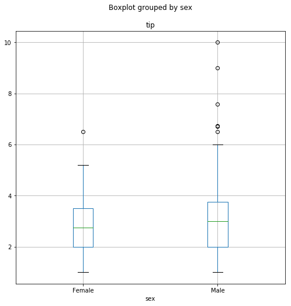

```python
#Create a boxplot
tips.boxplot('tip', by='sex', figsize=(8, 8))
```

[output not shown]

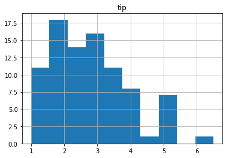

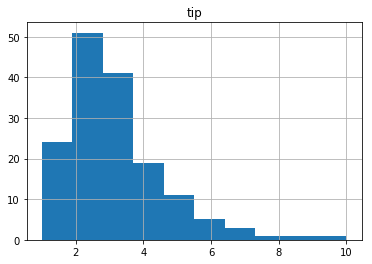

```python
# two graphs
tips.groupby('sex').hist('tip')
```

```python
# test if there is a significant difference in the mean of total bills of male and female

female_bill = tips[tips['sex'] == 'Female']['total_bill']
male_bill = tips[tips['sex'] == 'Male']['total_bill']
two_sample = stats.ttest_ind(female_bill, male_bill)
print "The t-statistic is %.3f and the p-value is %.3f." % two_sample
```

```
The t-statistic is -2.278 and the p-value is 0.024.
```

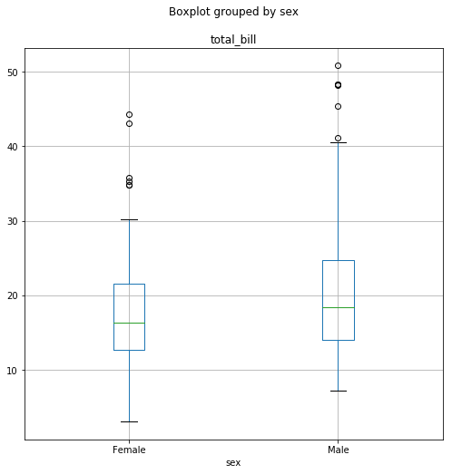

```python
#Create a boxplot with total_bill and sex

tips.boxplot('total_bill', by='sex', figsize=(8, 8))
```

```python
# test if there is a significant difference in the tip amount between smoker and non-smoker
smoker_tip= tips[tips['smoker'] == 'Yes']['tip']
non_smoker = tips[tips['smoker'] == 'No']['tip']
two_sample = stats.ttest_ind(smoker_tip, non_smoker)
print "The t-statistic is %.3f and the p-value is %.3f." % two_sample
```

```
The t-statistic is 0.092 and the p-value is 0.927.
```

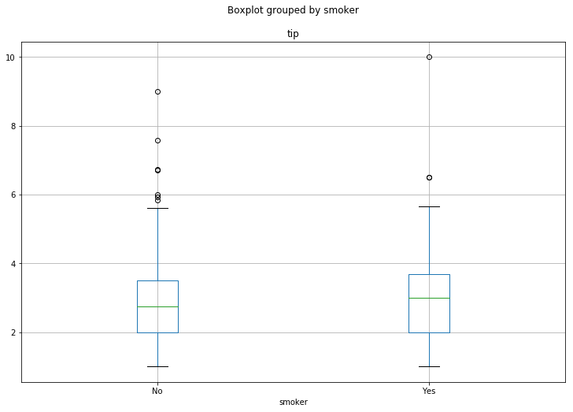

```python
#Create a boxplot with tip and smoker
tips.boxplot('tip', by='smoker',figsize=(12,8))
```